# Replication of Faber’s A Quantitative Approach to Tactical Asset Allocation - South Africa

#### Importing the data into R

Each asset’s class price series has been saved as a CSV. The packages used for performance analysis and backtesting require the data to be xts objects which are created by the following code.

```r
#remove past data
rm(list = ls(envir = globalenv()),envir = globalenv()) #clear Vars from global enviroment

#Load required packages
library(PerformanceAnalytics)
library(quantstrat)

#Set Symbols
symbols <- c("TBILLS","JALSH","MSCIWORLD","SA10YR","GSCI","JASPY","SACPI")

#Import saved pricing data csv files as xts
getSymbols(symbols,
           src = "csv",
           dir="../Data/CSV files/SA Long Term/",
           col.names=c("Close"))

#Define subset dates for different period
ReportingSubsetPeriod <- "1971-12-31::2016-12-31"
```

#### Calculating asset class returns and charting

Once the data is loaded we can create one xts object for the prices and calculate each asset class’s returns. The asset class returns are then charted.

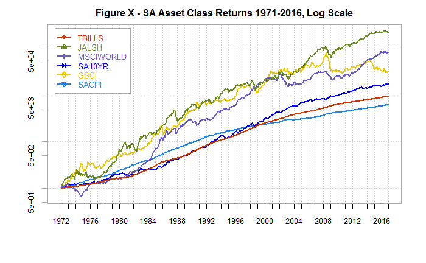

```r
AllAssets <- cbind.xts(Cl(TBILLS),
                       Cl(JALSH),
                       Cl(MSCIWORLD),
                       Cl(SA10YR),
                       Cl(GSCI),
                       #Cl(JSAPY),
                       Cl(SACPI))
#subset to required reporting period
ReportingSubsetPeriod <- "1971-12-31::2016-12-31"
AllAssets <- AllAssets[ReportingSubsetPeriod]
colnames(AllAssets) <- symbols[-6]
#calculate returns and cum returns
AllAssets.ret <- Return.calculate(AllAssets)[-1,]
AllAssets.cumret <- 100*cumprod(1+ ROC(AllAssets, type = "discrete")[-1,])
chart.TimeSeries(AllAssets.cumret[ReportingSubsetPeriod],
 main = paste("Figure X - SA Asset Class Returns ",substr(ReportingSubsetPeriod,1,4),"-",substr(ReportingSubsetPeriod,13,16),", Log Scale",sep = ""),
 ylab = "",
 ylog = TRUE,
 #ylim = c(50,200000),
 date.format = "%Y",
 major.ticks = "years",
 legend.loc = "topleft",
 colorset = c("orangered3","olivedrab","slateblue","blue","gold2","dodgerblue2","cornflowerblue"),
 minor.ticks =FALSE)
```

#### Analysing asset class returns, max drawdowns and other performance statistics

Using the package performance analytics, common performance statistics such as CAGR, volatility and sharpe ratios can be calculated.

```r
stats
```

```
                TBILLS  JALSH MSCIWORLD SA10YR   GSCI
Return           10.53  18.48     15.87  12.00  13.60
Volatility        1.26  20.99     17.42   7.35  22.88
Sharpe (10.53%)   0.00   0.34      0.28   0.18   0.12
MaxDD             0.00 -42.45    -49.90 -18.63 -64.08
Inflation CAGR    9.48   9.48      9.48   9.48   9.48
```

#### Managing Risk

Lets chart each asset with its 10 month simple moving average

```r
myChart_Theme <- chart_theme() #Create a chart_theme
myChart_Theme$col$line.col <- "blue"

SMAperiod <- 10

chart_Series(Cl(JALSH),
  name = paste("JALSH vs 10 Month Simple Moving Average",sep = ""),
  theme=myChart_Theme,
  type = "line",
  subset = SubsetPeriod,
  TA = 'add_SMA(n=SMAperiod, on=1, col="red")'
  )

chart_Series(Cl(MSCIWORLD),
  name = paste("MSCI World vs 10 Month Simple Moving Average",sep = ""),
  theme=myChart_Theme,
  type = "line",
  subset = SubsetPeriod,
  TA = 'add_SMA(n=SMAperiod, on=1, col="red")'
  )

chart_Series(Cl(SA10YR),
  name = paste("SA10YR vs 10 Month Simple Moving Average",sep = ""),
  theme=myChart_Theme,
  type = "line",
  subset = SubsetPeriod,
  TA = 'add_SMA(n=SMAperiod, on=1, col="red")'
  )

chart_Series(Cl(GSCI),
  name = paste("GSCI vs 10 Month Simple Moving Average",sep = ""),
  theme=myChart_Theme,
  type = "line",
  subset = SubsetPeriod,
  TA = 'add_SMA(n=SMAperiod, on=1, col="red")'
  )

# chart_Series(Cl(JSAPY),
#   name = paste("JSAPY vs 10 Month Simple Moving Average",sep = ""),
#   theme=myChart_Theme,
#   type = "line",
#   subset = SubsetPeriod,
#   TA = 'add_SMA(n=SMAperiod, on=1, col="red")'
#   )

#change to other chart so can make it log?
```

[output not shown]

#### Calculating returns

```r
#Import saved pricing data csv files as xts
getSymbols("TBILLYIELDS",
           src = "csv",
           dir="../Data/CSV files/SA Long Term/",
           col.names=c("Close"))
```

```
[1] "TBILLYIELDS"
```

```r
#TBILLYIELDS <- TBILLYIELDS[SubsetPeriod]
#load an additional library
library(dplyr)
#Create new all assets
AllAssets <- cbind.xts(Cl(JALSH),
                       Cl(MSCIWORLD),
                       Cl(SA10YR),
                       Cl(GSCI),
                       #Cl(JASPY),
                       Cl(TBILLYIELDS))
#subset to include period before actual start date to be able to calculate simple moving averages
SubsetPeriod <- "1971-01-31::2016-12-31"
AllAssets <- AllAssets[SubsetPeriod]
#create dataframe - tidyverse not compatible with xts?
AllAssets.df <- data.frame(date=index(AllAssets), coredata(AllAssets)) #, row.names = index(AllAssets))
# AllAssets.df  <- mutate(AllAssets.df,
#                         RF1.ret = lag((TBILLYIELDS.Close/100)/12),
#                         RF.ret =  c(0,lag((TBILLYIELDS.Close/100)/12)[-1]))
#mutate new columns
AllAssets.df  <- mutate(AllAssets.df,
  "RF.ret" =  c(0,lag((TBILLYIELDS.Close/100)/12)[-1]),

  "JALSH.ret" =  c(0,diff(JALSH.Close)/lag(JALSH.Close)[-1]),
  "JALSH.2m.SMA" =  rollmean(JALSH.Close,2,fill = 0,align = "right"),
  "JALSH.5m.SMA" =  rollmean(JALSH.Close,5,fill = 0,align = "right"),
  "JALSH.10m.SMA" =  rollmean(JALSH.Close,10,fill = 0,align = "right"),
  "JALSH.2m.signal" =  lag(ifelse(JALSH.Close>=JALSH.2m.SMA,1,0)),
  "JALSH.5m.signal" =  lag(ifelse(JALSH.Close>=JALSH.5m.SMA,1,0)),
  "JALSH.10m.signal" =  lag(ifelse(JALSH.Close>=JALSH.10m.SMA,1,0)),
  "JALSH.2m.timingret" = ifelse(JALSH.2m.signal == 1,JALSH.ret,RF.ret),
  "JALSH.5m.timingret" = ifelse(JALSH.5m.signal == 1,JALSH.ret,RF.ret),
  "JALSH.10m.timingret" = ifelse(JALSH.10m.signal == 1,JALSH.ret,RF.ret),
  "JALSH.avg.timingret" = (JALSH.2m.timingret + JALSH.5m.timingret + JALSH.10m.timingret)/3,
  "MSCIWORLD.ret" =  c(0,diff(MSCIWORLD.Close)/lag(MSCIWORLD.Close)[-1]),
  "MSCIWORLD.2m.SMA" =  rollmean(MSCIWORLD.Close,2,fill = 0,align = "right"),
  "MSCIWORLD.5m.SMA" =  rollmean(MSCIWORLD.Close,5,fill = 0,align = "right"),
  "MSCIWORLD.10m.SMA" =  rollmean(MSCIWORLD.Close,10,fill = 0,align = "right"),
  "MSCIWORLD.2m.signal" =  lag(ifelse(MSCIWORLD.Close>=MSCIWORLD.2m.SMA,1,0)),
  "MSCIWORLD.5m.signal" =  lag(ifelse(MSCIWORLD.Close>=MSCIWORLD.5m.SMA,1,0)),
  "MSCIWORLD.10m.signal" =  lag(ifelse(MSCIWORLD.Close>=MSCIWORLD.10m.SMA,1,0)),
  "MSCIWORLD.2m.timingret" = ifelse(MSCIWORLD.2m.signal == 1,MSCIWORLD.ret,RF.ret),
  "MSCIWORLD.5m.timingret" = ifelse(MSCIWORLD.5m.signal == 1,MSCIWORLD.ret,RF.ret),
  "MSCIWORLD.10m.timingret" = ifelse(MSCIWORLD.10m.signal == 1,MSCIWORLD.ret,RF.ret),
  "MSCIWORLD.avg.timingret" = (MSCIWORLD.2m.timingret + MSCIWORLD.5m.timingret + MSCIWORLD.10m.timingret)/3,

  "SA10YR.ret" =  c(0,diff(SA10YR.Close)/lag(SA10YR.Close)[-1]),
  "SA10YR.2m.SMA" =  rollmean(SA10YR.Close,2,fill = 0,align = "right"),
  "SA10YR.5m.SMA" =  rollmean(SA10YR.Close,5,fill = 0,align = "right"),
  "SA10YR.10m.SMA" =  rollmean(SA10YR.Close,10,fill = 0,align = "right"),
  "SA10YR.2m.signal" =  lag(ifelse(SA10YR.Close>=SA10YR.2m.SMA,1,0)),
  "SA10YR.5m.signal" =  lag(ifelse(SA10YR.Close>=SA10YR.5m.SMA,1,0)),
  "SA10YR.10m.signal" =  lag(ifelse(SA10YR.Close>=SA10YR.10m.SMA,1,0)),
  "SA10YR.2m.timingret" = ifelse(SA10YR.2m.signal == 1,SA10YR.ret,RF.ret),
  "SA10YR.5m.timingret" = ifelse(SA10YR.5m.signal == 1,SA10YR.ret,RF.ret),
  "SA10YR.10m.timingret" = ifelse(SA10YR.10m.signal == 1,SA10YR.ret,RF.ret),
  "SA10YR.avg.timingret" = (SA10YR.2m.timingret + SA10YR.5m.timingret + SA10YR.10m.timingret)/3,

  "GSCI.ret" =  c(0,diff(GSCI.Close)/lag(GSCI.Close)[-1]),
  "GSCI.2m.SMA" =  rollmean(GSCI.Close,2,fill = 0,align = "right"),
  "GSCI.5m.SMA" =  rollmean(GSCI.Close,5,fill = 0,align = "right"),
  "GSCI.10m.SMA" =  rollmean(GSCI.Close,10,fill = 0,align = "right"),
  "GSCI.2m.signal" =  lag(ifelse(GSCI.Close>=GSCI.2m.SMA,1,0)),
  "GSCI.5m.signal" =  lag(ifelse(GSCI.Close>=GSCI.5m.SMA,1,0)),
  "GSCI.10m.signal" =  lag(ifelse(GSCI.Close>=GSCI.10m.SMA,1,0)),
  "GSCI.2m.timingret" = ifelse(GSCI.2m.signal == 1,GSCI.ret,RF.ret),
  "GSCI.5m.timingret" = ifelse(GSCI.5m.signal == 1,GSCI.ret,RF.ret),
  "GSCI.10m.timingret" = ifelse(GSCI.10m.signal == 1,GSCI.ret,RF.ret),
  "GSCI.avg.timingret" = (GSCI.2m.timingret + GSCI.5m.timingret + GSCI.10m.timingret)/3,
  "Timing.ret" = (JALSH.10m.timingret + MSCIWORLD.10m.timingret + SA10YR.10m.timingret + GSCI.10m.timingret)/4,
  "BuyandHold.ret" = (JALSH.ret + MSCIWORLD.ret + SA10YR.ret + GSCI.ret)/4,
  "Avg.Timing.ret" = (JALSH.avg.timingret + MSCIWORLD.avg.timingret + SA10YR.avg.timingret + GSCI.avg.timingret)/4

  )
rownames(AllAssets.df) <- index(AllAssets)
#Create xts of calculations to analyse performance
AllAssets.xts <- xts(AllAssets.df[,-1], order.by = AllAssets.df$date)
#detach the packagae dplyr as it isn't compatible with other packages?
detach(package:dplyr)
```

#### Individual Asset class charts buy and hold vs timing

CHECK THIS!!!!!

[figure not shown]

```r
stats <- rbind(Return.annualized(Returns,scale = 12)*100,
               StdDev.annualized(Returns,scale = 12)*100,
               SharpeRatio.annualized(Returns,Rf = Rf.ret$TBILLYIELDS.Close),
               maxDrawdown(Returns,scale = 12,invert = FALSE)*100)
               #c(nrow(subset(Returns, Returns$JALSH.ret >= 0))/nrow(Returns),
              #   nrow(subset(Returns, Returns$JALSH.timingret >= 0))/nrow(Returns))*100,
               #  nrow(subset(Returns, Returns$JALSH.timingret >= 0))/nrow(Returns))*100))
colnames(stats) <- c("Buy and Hold","Timing","Average Timing")
rownames(stats) <- c("Return",
                     "Volatility",
                     "Sharpe",
                     "MaxDD")
                     #"% Positive Months")
round(stats,2)
```

```
           Buy and Hold Timing Average Timing
Return            16.25  17.33          15.86
Volatility        17.57  15.07          13.53
Sharpe             0.71   0.89           0.89
MaxDD            -49.90 -20.54         -19.17
```

```r
write.table(round(stats,4), "clipboard", sep="\t", col.names=NA)
```

#### GTAA Performance Charts

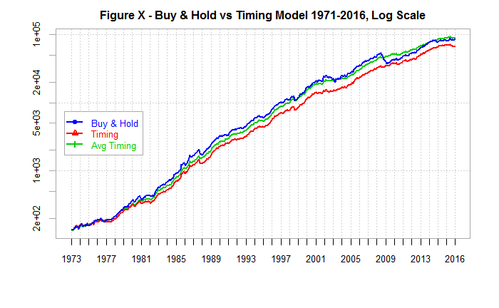

```r
SubsetPeriod <- "1971-12-31::2016-12-31"
Returns <- cbind.xts(AllAssets.xts$BuyandHold.ret,AllAssets.xts$Timing.ret,AllAssets.xts$Avg.Timing.ret)[SubsetPeriod]
CumReturns <- 100*cumprod(1+Returns[-1,])
colnames(CumReturns) <- c("Buy & Hold","Timing","Avg Timing")
chart.TimeSeries(CumReturns["1973-01-31::2016-12-31"],
  main = paste("Figure X - Buy & Hold vs Timing Model ",substr(SubsetPeriod,1,4),"-",substr(SubsetPeriod,13,16),", Log Scale",sep = ""),
  date.format = "%Y",
  colorset = c(4,2,3),
  ylab = "",
  ylog = TRUE,
  #ylim = c(100,500),
  legend.loc = "left",
  major.ticks = "years",
  minor.ticks = FALSE)
```

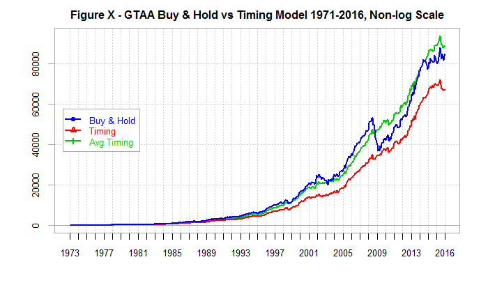

```r
chart.TimeSeries(CumReturns["1973-01-31::2016-12-31"],
  main = paste("Figure X - GTAA Buy & Hold vs Timing Model ",substr(SubsetPeriod,1,4),"-",substr(SubsetPeriod,13,16),", Non-log Scale",sep = ""),
  date.format = "%Y",
  colorset = c(4,2,3),
  ylab = "",
  ylog = FALSE,
  #ylim = c(100,500),
  legend.loc = "left",
  major.ticks = "years",
  minor.ticks = FALSE)
```

need proper yield curve! how does this compare to USA?

```r
SubsetPeriod <- "1971-12-31::2016-12-31"
Rf.ret <- Return.calculate(TBILLS)[-1,]
Rf.ret <- Rf.ret[SubsetPeriod]
Returns <- cbind.xts(AllAssets.xts$BuyandHold.ret,AllAssets.xts$Timing.ret,AllAssets.xts$Avg.Timing.ret)[SubsetPeriod]
stats <- rbind(100*Return.annualized(Returns,scale = 12),
               100*StdDev.annualized(Returns,scale = 12),
               SharpeRatio.annualized(Returns,Rf = Rf.ret$TBILLS.Close),
               #SortinoRatio(Returns, MAR = 0),
               100*maxDrawdown(Returns,invert = FALSE),
               100*c(Return.annualized(Return.calculate(Cl(SACPI))[SubsetPeriod],scale = 12))
               )
colnames(stats) <- c("Buy & Hold","Timing","Avg Timing")
rownames(stats) <- c("Return",
                     "Volatility",
                     "Sharpe",
                     #"Sortino",
                     "MaxDD",
                     "Inflation CAGR")
round(stats,2)
```

```
               Buy & Hold Timing Avg Timing
Return              16.36  15.63      16.39
Volatility          10.95   8.76       7.87
Sharpe               0.49   0.53       0.68
MaxDD              -30.61 -11.59      -7.29
Inflation CAGR       9.46   9.46       9.46
```

```r
write.table(round(stats,4), "clipboard", sep="\t", col.names=NA)
#look to add skewness/ kurtosis
```

so better sharpe? [confirm calc method/fix interest rate… should i calc manually?] and less maxdd whats kurtosis, information ratio, skew. ask what metrics rad, mb and emyln use… run on longer dater in asset allocation ratios

last 12 months, 3 years, etc returns

rolling returns

to do:

- how to calculate dailyreturns with NA
- check returns make sense - effect of zar?
- compare to US / JPY
- create RF to get 2002 in

To do: SA assets Daily drawdowns monthly returns table Relative performance / rolling perofrmance / alpha 10 worst periods / 10 best periods do different averages improve SA - check robustness of averages….